# Discussing NP-Completeness of Sudoku Game

Ruby(Ziheng) Ru, Kristen(Zidan) Huang, Lingge Nox Yu

**Introduction**:

Sudoku is an ancient number puzzle adapted from a mathematical concept called Latin square. The game originated in Switzerland and traveled to Japan, where it gained popularity and was renamed Sudoku, which means “the numbers must be single” in Japanese.[^1]

The rules of the Sudoku game are simple. It is all about filling a $n^{2}$ $\times$ $n^{2}$ board with integers ranging from 1 - $n^{2}$, where each row, column, and $n$ $\times$ $n$ box does not contain duplicate integer (Figure 0[^2]).

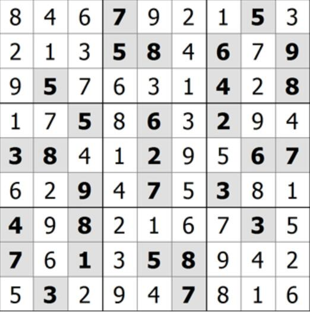

Figure 0: Solution to a typical 9*9 Sudoku problem

**Proof: Sudoku is NP-complete**

*Sudoku is in NP*

We can easily build a polynomial verifier to confirm if a $n^{2}$ $\times$ $n^{2}$ solution to a Sudoku board is correct. We simply go through every column, row, and box to check if there are duplicate integers. If there is, we reject.

Since this verifier should run in O($n^{2}$) time, the Sudoku problem is in NP.

*Big Idea*

$$\begin{aligned}
3SAT \leq_{p} Triangulated \ tripartite \leq_{p} Latin \ square \leq_{p}Sudoku\\
\end{aligned}$$
The reduction from a triangulated tripartite to 3SAT is essential, but it will not be discussed extensively here due to its complexity.

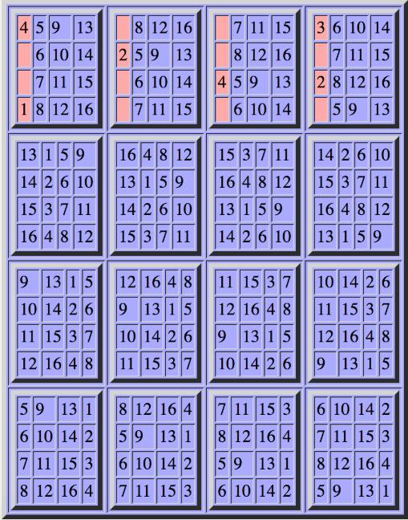

*Proof: Triangulated Tripartite $\leq_{p}$ Latin square*

A tripartite (Figure 3[^4]) is a graph whose nodes can be divided into three subsets. Each subset of a tripartite should have the same number of nodes, and there should not be an edge between nodes of the same subset.

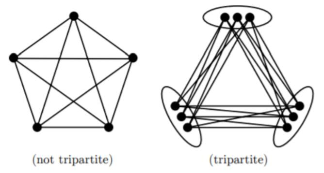

Figure 3: A good (right) and bad (left) tripartite

To triangulate a graph (Figure $4^{4}$) means to divide a graph’s edges into multiple subsets. Each subset should have exactly three edges that can form a triangle on their own. Every triangle in a properly triangulated graph should have edges disjoint from every other triangle in the graph (i.e. no two triangles should share an edge).

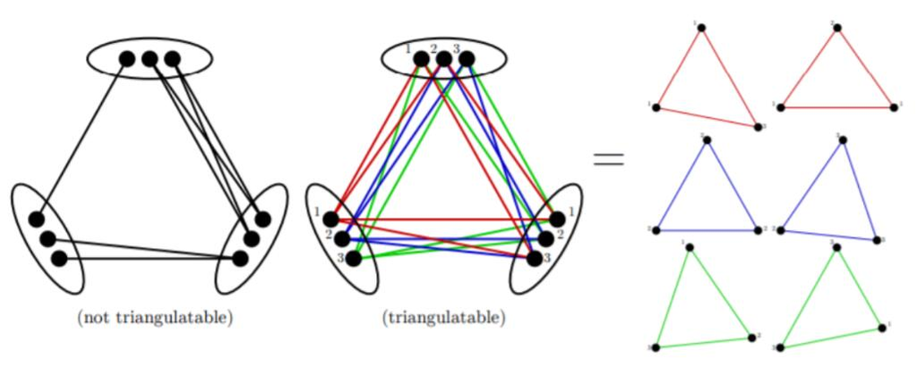

Figure 4: A triangulatable (right) and non-triangulatable (left) grah. All triangles in a triangulatable graph must have disjoint edges.

Now we can explain how to convert a Latin square into a triangulated tripartite. First, we construct a tripartite $G$ with subsets of nodes $Vc, Vr, Vs$ corresponding to the rows, columns, and symbols (integers) of the Latin square. When we fill a symbol, say $k$, to $cell (i,j)$ in the Latin square, we associate that filled cell with $\bigtriangleup$$(ri, cj, sk)$ in the tripartite (Figure $5^{4}$).

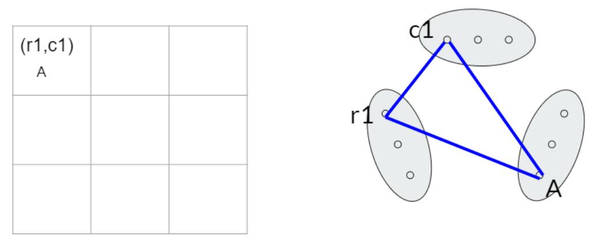

Figure 5: filling $cell (1,1)$ in the partial Latin square with symbol $k$ corresponds to making a triangle $\bigtriangleup$$r_{1}, c_1, s_k$ in the corresponding tripartite

Therefore, when we have completed a Latin square and verified the answers are correct, we should be able to obtain a corresponding fully triangulated tripartite (Figure $6^{4}$ ). YAY!

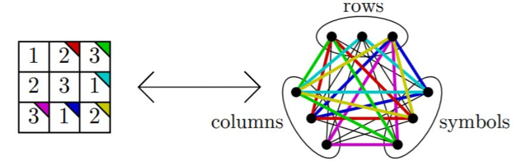

Figure 6: A correct solution to a partial Latin square corresponds to a fully triangulated tripartite

**Discussion**

*Assessment*

Takayuki demonstrated the reduction from Sudoku to Latin square in his master’s thesis in 2003 [^5]. He also referred to another paper [^6] that proved the Latin square problem is NP-complete. However, neither paper demonstrated a reduction of $Latin$ $square$ or $Sudoku$ to an NP-complete problem we are familiar with. Due to the complexity of the reduction from $Triangulated$ $tripartite$ to $3SAT$, we are uncertain about how to explain it in plain context. If you are interested in learning about this reduction, please check out this lecture note $^{4}$.

*Connections to the real-world context*

We learned how to prove NP-completeness through reductions. We are now able to apply that to demonstrate the NP-completeness of a popular game! Algorithms such as Dancing links and backtracking can be used to solve Sudoku if its size is small. Understanding how Sudoku is NP-complete gives us insight into how algorithms like these can solve other NP-complete problems.

*Shortcomings*

Future research should investigate the implications of Latin square on problems related to Computer Science. The result that proves Sudoku is NP-Complete can be applied in other areas besides in entertainment.

**Contributions**

Almost all of the work was done during group meetings. All three members showed up to every group meeting and worked collectively on presentation and web page.

**References:**

[^1]: Sudoku History http://www.sudokudragon.com/sudokuhistory.htm
[^2]: Laboratory News, April Sudoku Answers, 2012 https://www.labnews.co.uk/puzzles/april-sudoku-answers-10-04-2012/
[^3]: NP-compleness of sudoku http://www.cs.ox.ac.uk/people/paul.goldberg/FCS/sudoku.html
[^4]: Bartlett, Padraic. (2014). Mini Lecture 7: 3SAT and Latin Square. http://web.math.ucsb.edu/~padraic/ucsb_2013_14/mathcs103_s2014/mathcs103_s2014_mlecture7.pdf
[^5]: Yato, Takayuki. (2003). Complexity and completeness of finding another solution and its application to puzzles. (Unpublished master’s thesis, The university of Tokyo, Tokyo, Japan). http://www-imai.is.s.u-tokyo.ac.jp/~yato/data2/MasterThesis.pdf.
[^6]: C. J. Colbourn, M. J. Colbourn, and D. R. Stinson. The computational complexity of recognizing critical sets. In Graph theory, Singapore 1983, number 1073 in Lecture Note in Math., pages 248-253. Springer, 1984. https://core.ac.uk/download/pdf/81928286.pdf